# Inf Stats Assignment

MT

12/7/2020

## Sypnosis

```r
knitr::opts_chunk$set(echo = TRUE)
```

### Part 1: Simulation Exercise

#### 1.1 Show the sample mean and compare it to the theroretical mean of the distribution

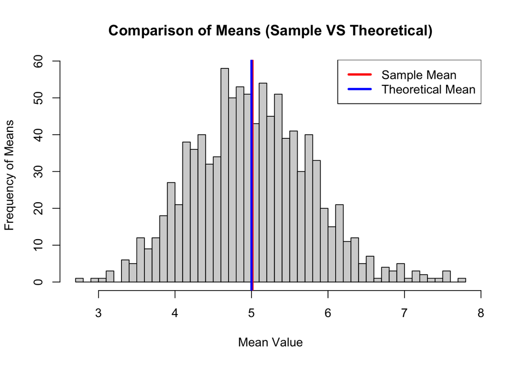

```r
lambda<- 0.2
n<- 40
set.seed(123)
sim<- matrix(rexp(n*1000,lambda), nrow=1000,ncol=40)
meansim<- apply(sim, 1, mean)
hist(meansim, breaks=40,
        main = "Comparison of Means (Sample VS Theoretical)", xlab = "Mean Value", ylab = "Frequency of Means")
abline(v = mean(meansim), lty=1, lwd=3, col= "red")
abline(v= 1/lambda, lty = 1, lwd=3, col= "blue")
legend("topright", lty=1, lwd=3, col=c("red", "blue"), legend = c("Sample Mean", "Theoretical Mean"))
```

#### 1.2 Show how varible the sample is (via variance) and compare it to the theoretical variance of the ditribution

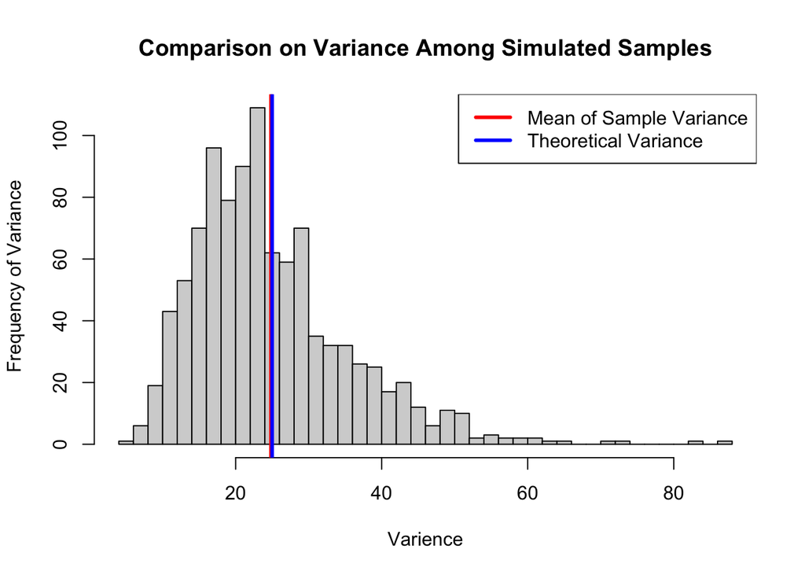

```r
lambda<- 0.2
n<- 40
set.seed(123)
sim<- matrix(rexp(n*1000,lambda), nrow=1000,ncol=40)
varsim<- apply(sim, 1, var)
hist(varsim, breaks = 40,
        main = "Comparison on Variance Among Simulated Samples", xlab="Varience", ylab="Frequency of Variance")
abline(v = mean(varsim), lty=1, lwd=3, col= "red")
abline(v= (1/lambda)^2, lty = 1, lwd=3, col= "blue")
legend("topright", lty=1, lwd=3, col=c("red", "blue"), legend = c("Mean of Sample Variance", "Theoretical Variance"))
```

#### 1.3 Show the distribution is approximately normal

##### Normal Distribution by curve

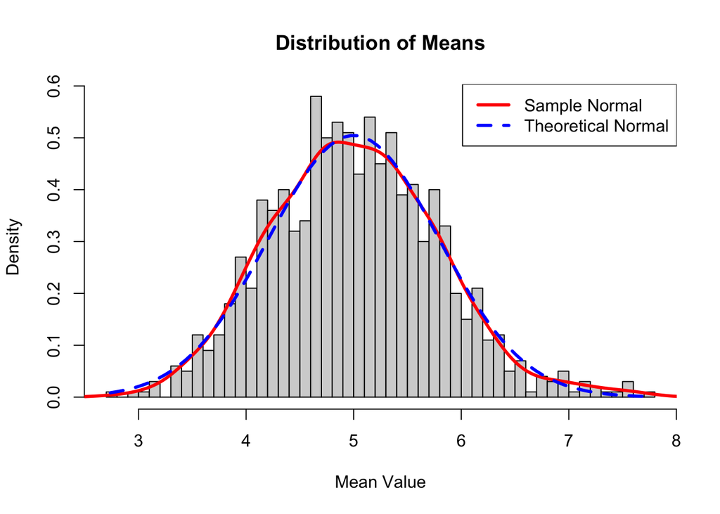

```r
lambda<- 0.2
n<- 40
set.seed(123)
sim<- matrix(rexp(n*1000,lambda), nrow=1000,ncol=40)
meansim<- apply(sim, 1, mean)
hist(meansim, breaks=40, probability = T,
        main = "Distribution of Means", xlab = "Mean Value", ylab = "Density")
lines(density(meansim), lwd= 3, col="red")

# Normal distribution line creation
x <- seq(min(meansim), max(meansim), length=2*n)
y <- dnorm(x, mean=1/lambda, sd=sqrt(((1/lambda)/sqrt(n))^2))
lines(x,y, pch=22, col="blue", lwd=3, lty=2)
legend("topright", lty=c(1,2), lwd=3, col=c("red", "blue"), legend = c("Sample Normal", "Theoretical Normal"))
```

##### Normal Distribution by Comparing CI

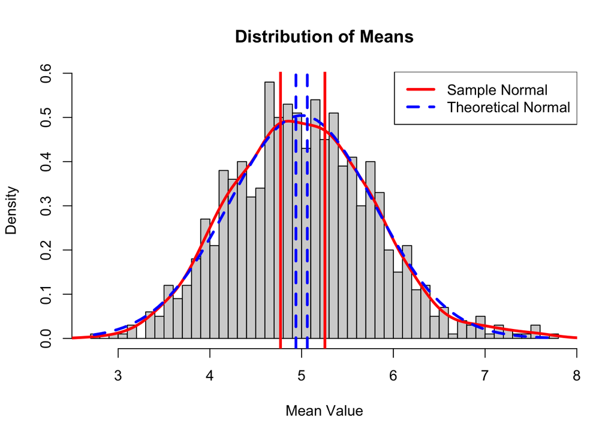

```r
lambda<- 0.2
n<- 40
set.seed(123)
sim<- matrix(rexp(n*1000,lambda), nrow=1000,ncol=40)
meansim<- apply(sim, 1, mean)
simci<- round(mean(meansim) +c(-1,1)*1.96*sd(meansim)/sqrt(n),3)
tci<- round(1/lambda +c(-1,1)*1.96*lambda/sqrt(n),3)
hist(meansim, breaks=40, probability = T,
        main = "Distribution of Means", xlab = "Mean Value", ylab = "Density")
lines(density(meansim), lwd= 3, col="red")

# Normal distribution line creation
x <- seq(min(meansim), max(meansim), length=2*n)
y <- dnorm(x, mean=1/lambda, sd=sqrt(((1/lambda)/sqrt(n))^2))
lines(x,y, pch=22, col="blue", lwd=3, lty=2)
legend("topright", lty=c(1,2), lwd=3, col=c("red", "blue"), legend = c("Sample Normal", "Theoretical Normal"))
abline(v = simci, lty=1, lwd=3, col="Red")
abline(v=tci, lty=2, lwd=3, col="Blue")
```

### Part 2: Basic Inferential Data Analysis Instructions.

#### 2.1 Load the ToothGrowh Data and perform some basic exploratory data analyses

```r
library(ggplot2)
data("ToothGrowth")
summary(ToothGrowth)
```

```
##       len        supp         dose
##  Min.   : 4.20   OJ:30   Min.   :0.500
##  1st Qu.:13.07   VC:30   1st Qu.:0.500
##  Median :19.25           Median :1.000
##  Mean   :18.81           Mean   :1.167
##  3rd Qu.:25.27           3rd Qu.:2.000
##  Max.   :33.90           Max.   :2.000
```

```r
str(ToothGrowth)
```

```
## 'data.frame':    60 obs. of  3 variables:
##  $ len : num  4.2 11.5 7.3 5.8 6.4 10 11.2 11.2 5.2 7 ...
##  $ supp: Factor w/ 2 levels "OJ","VC": 2 2 2 2 2 2 2 2 2 2 ...
##  $ dose: num  0.5 0.5 0.5 0.5 0.5 0.5 0.5 0.5 0.5 0.5 ...
```

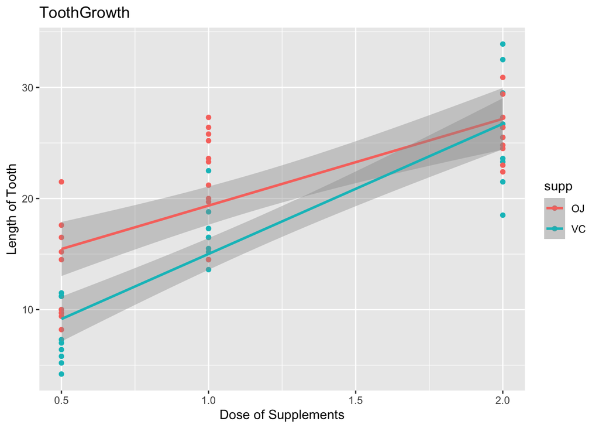

```r
qplot(dose, len, data = ToothGrowth, colour=supp, geom="point") + geom_smooth(method = "lm") +
        labs(title= "ToothGrowth", x= "Dose of Supplements", y= "Length of Tooth")
```

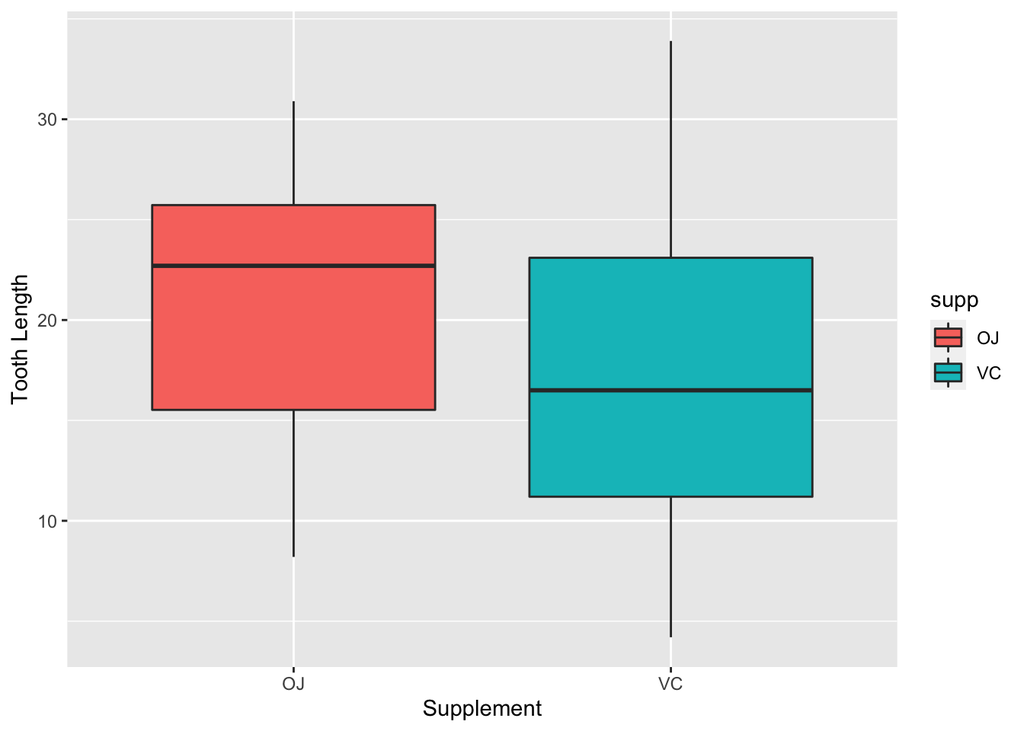

```r
ggplot(aes(x = supp, y = len), data = ToothGrowth) +
        geom_boxplot(aes(fill = supp))+
        labs(x="Supplement",y="Tooth Length")
```

#### 2.2 Provide basic summary of the data

Quick observations from the plots, tells us that the length of tooth does increase as the dosage increases for both supplement.When compared between the mean of two supplement as a whole, their means were found between the CI of each supplement. Also, both supplements starts to converge with little difference at 2.0 dose and might suggest that there is no difference between each supplement at high dosage. More statistical analysis are required to define if there’s a significant difference between the supplements and at which dosage is the effective ones.

#### 2.3 Use confidence interval and/or hypothesis test to compare tooth growth by supp and dose. (only use the techniques from class, even if there’s otehr approaches worth considering)

##### Based on Supplement

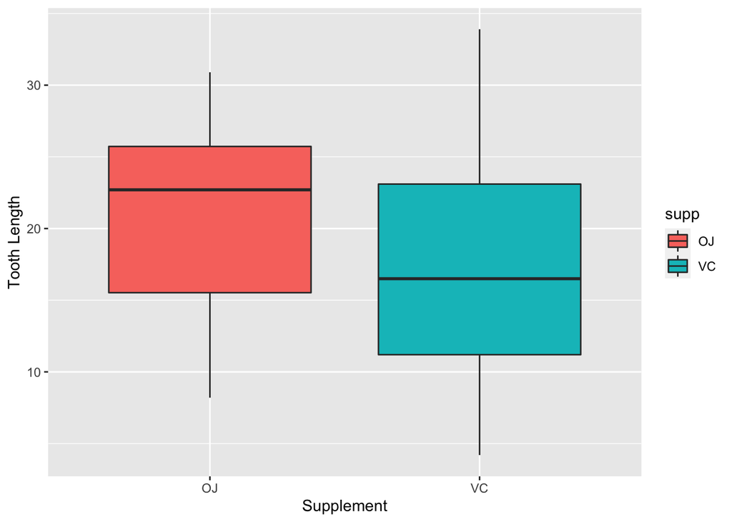

```r
ggplot(aes(x = supp, y = len), data = ToothGrowth) +
        geom_boxplot(aes(fill = supp))+
        labs(x="Supplement",y="Tooth Length")
```

```r
t.test(len~supp, data=ToothGrowth)
```

```
##
##  Welch Two Sample t-test
##
## data:  len by supp
## t = 1.9153, df = 55.309, p-value = 0.06063
## alternative hypothesis: true difference in means is not equal to 0
## 95 percent confidence interval:
##  -0.1710156  7.5710156
## sample estimates:
## mean in group OJ mean in group VC
##         20.66333         16.96333
```

##### Base on Supplement Factor

```r
t.test(len~supp, data=subset(ToothGrowth, dose == "0.5"))$p.value
```

```
## [1] 0.006358607
```

```r
t.test(len~supp, data=subset(ToothGrowth, dose == "1"))$p.value
```

```
## [1] 0.001038376
```

```r
t.test(len~supp, data=subset(ToothGrowth, dose == "2"))$p.value
```

```
## [1] 0.9638516
```

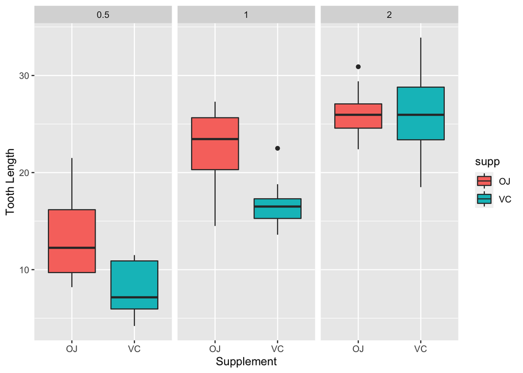

```r
ggplot(aes(x = supp, y = len), data = ToothGrowth) +
        geom_boxplot(aes(fill = supp)) +
        facet_wrap(~ dose)+
        labs(x="Supplement",y="Tooth Length")
```

By comparing the supplements at each dosage level, it was observed that supplements at 0.5 and 1.0 seems to have significant difference between each other. However, as observed in the exploratory plot at 2.0 dosage does not have significant differences observed with means within the range of each other’s confidence intervals. Hence, we are able to reject null hypothesis for 3,4 but we are not able to reject 5.

##### Base on Dosage Factor for each Supplement

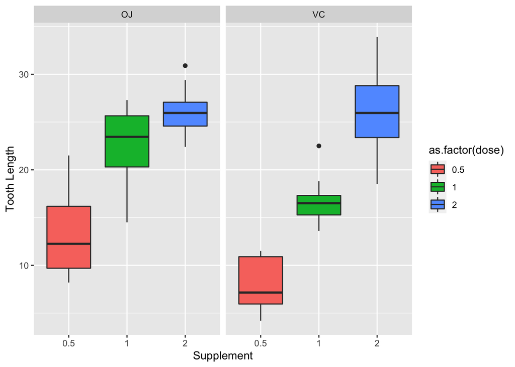

```r
ggplot(aes(x = as.factor(dose), y = len), data = ToothGrowth) +
        geom_boxplot(aes(fill = as.factor(dose))) +
        facet_wrap(~ supp)+
        labs(x="Supplement",y="Tooth Length")
```

```r
H6<- t.test(len~dose, data=subset(ToothGrowth, ToothGrowth$dose != 2 & ToothGrowth$supp !="VC" ))$p.value
H7<- t.test(len~dose, data=subset(ToothGrowth, ToothGrowth$dose != 0.5 & ToothGrowth$supp !="VC" ))$p.value
H8<- t.test(len~dose, data=subset(ToothGrowth, ToothGrowth$dose != 1 & ToothGrowth$supp !="VC" ))$p.value
H9<- t.test(len~dose, data=subset(ToothGrowth, ToothGrowth$dose != 2 & ToothGrowth$supp !="OJ" ))$p.value
H10<- t.test(len~dose, data=subset(ToothGrowth, ToothGrowth$dose != 0.5 & ToothGrowth$supp !="OJ" ))$p.value
H11<- t.test(len~dose, data=subset(ToothGrowth, ToothGrowth$dose != 1 & ToothGrowth$supp !="OJ" ))$p.value
table(H6,H7,H8,H9,H10,H11)
```

```
## , , H8 = 1.32378387769723e-06, H9 = 6.81101770286506e-07, H10 = 9.15560305663865e-05, H11 = 4.6815774144921e-08
##
##                      H7
## H6                    0.0391951420462442
##   8.7849190551615e-05                  1
```

All of the null hypothesis 6-11 are rejected as the p-values of hypothesis showed significant difference between each of the dosage for each of the sample.